# Gender bias in speakers and career position

# Data

Data description and summary statistics in script `0_data_summary`.

```r
load(here("data_clean", "data_proportion.Rdata"))
load(here("data_clean", "data_pop_ppge.Rdata"))
data <- data_p
```

Creating dummy column to indicate if the speaker is a female (1) or not (0)

```r
data$fem <- 1
data$fem[data$gender == "M"] <- 0
```

# Modeling all data

Proportions of female speakers by academic level, before and after affirmative actions.

Mixed effects model, including year as random intercept.

Binomial distribution.

```r
mod0 <- glmmTMB(fem ~ 1 + (1|year),
              family=binomial, data = data)
mod1 <- glmmTMB(fem ~ affirm_action  + (1|year),
              family=binomial, data = data)
mod2 <- glmmTMB(fem ~ position_cat + (1|year),
              family=binomial, data = data)
mod3 <- glmmTMB(fem ~ position_cat + affirm_action + (1|year),
              family=binomial, data = data)
mod4 <- glmmTMB(fem ~ position_cat*affirm_action + (1|year),
              family=binomial, data = data)

kable(AICtab(mod0,mod1,mod2,mod3,mod4, base=T, weights=T), digits=2)
```

|  | AIC | dAIC | df | weight |
| --- | --- | --- | --- | --- |
| mod4 | 422.53 | 0.00 | 7 | 0.53 |
| mod2 | 423.56 | 1.03 | 4 | 0.32 |
| mod3 | 425.08 | 2.55 | 5 | 0.15 |
| mod0 | 440.30 | 17.77 | 2 | 0.00 |
| mod1 | 441.18 | 18.65 | 3 | 0.00 |

## Residual diagnostic of the selected models

Using the `DHARMa` package.

The two most plausible models presented a satisfactory residual diagnostic.

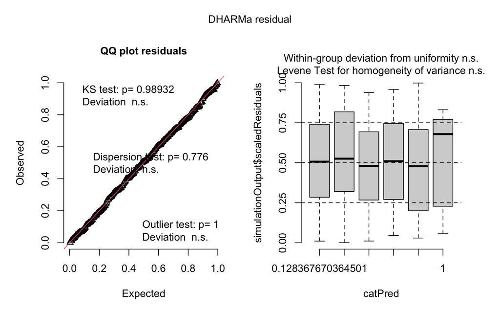

```r
plot(simulateResiduals(mod4))
```

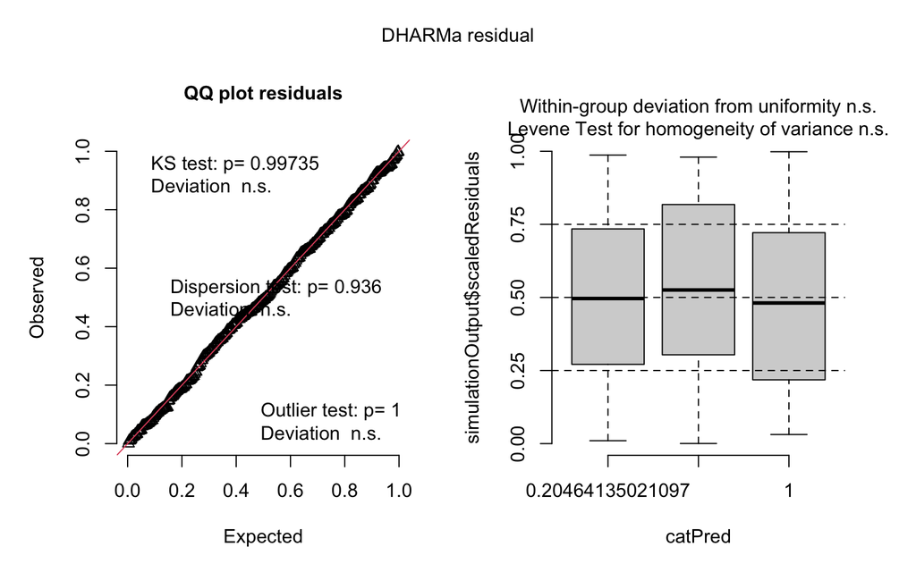

```r
plot(simulateResiduals(mod2))
```

## Models results

Predicting the proportion of female speakers fixing the population gender ration at 1 (1:1).

```r
summary(mod4)
```

```
##  Family: binomial  ( logit )
## Formula:          fem ~ position_cat * affirm_action + (1 | year)
## Data: data
##
##      AIC      BIC   logLik deviance df.resid
##    422.5    448.9   -204.3    408.5      313
##
## Random effects:
##
## Conditional model:
##  Groups Name        Variance Std.Dev.
##  year   (Intercept) 0.1203   0.3469
## Number of obs: 320, groups:  year, 12
##
## Conditional model:
##                                          Estimate Std. Error z value Pr(>|z|)
## (Intercept)                                0.2562     0.2233   1.147   0.2513
## position_catpostdoc                       -0.7171     0.3633  -1.974   0.0484 *
## position_catprofessor                     -1.6035     0.3496  -4.587 4.51e-06 ***
## affirm_actionafter                        -0.2999     0.4483  -0.669   0.5035
## position_catpostdoc:affirm_actionafter     1.6201     0.8402   1.928   0.0538 .
## position_catprofessor:affirm_actionafter   1.3933     0.6855   2.033   0.0421 *
## ---
## Signif. codes:  0 '***' 0.001 '**' 0.01 '*' 0.05 '.' 0.1 ' ' 1
```

```r
performance::r2(mod4)
```

```
## # R2 for Mixed Models
##
##   Conditional R2: 0.147
##      Marginal R2: 0.116
```

```r
my4 <- ggpredict(mod4, terms=c("position_cat","affirm_action"))
```

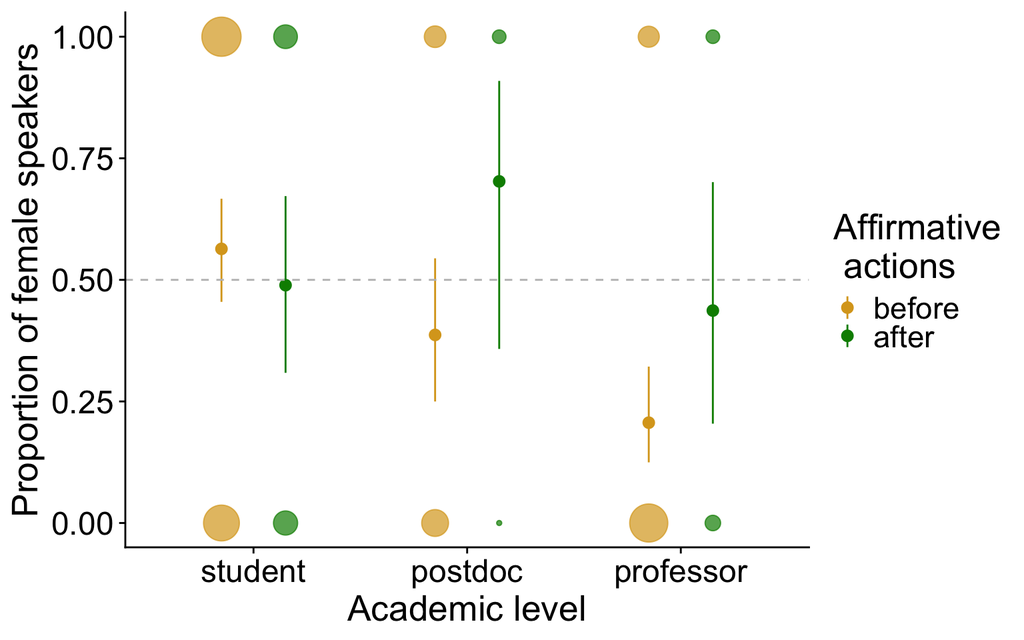

```r
summary(mod2)
```

```
##  Family: binomial  ( logit )
## Formula:          fem ~ position_cat + (1 | year)
## Data: data
##
##      AIC      BIC   logLik deviance df.resid
##    423.6    438.6   -207.8    415.6      316
##
## Random effects:
##
## Conditional model:
##  Groups Name        Variance Std.Dev.
##  year   (Intercept) 0.113    0.3361
## Number of obs: 320, groups:  year, 12
##
## Conditional model:
##                       Estimate Std. Error z value Pr(>|z|)
## (Intercept)             0.1582     0.1889   0.837    0.402
## position_catpostdoc    -0.3873     0.3162  -1.225    0.221
## position_catprofessor  -1.2770     0.2939  -4.345  1.4e-05 ***
## ---
## Signif. codes:  0 '***' 0.001 '**' 0.01 '*' 0.05 '.' 0.1 ' ' 1
```

```r
performance::r2(mod2)
```

```
## # R2 for Mixed Models
##
##   Conditional R2: 0.115
##      Marginal R2: 0.084
```

```r
my2 <- ggpredict(mod2, terms=c( "position_cat"))
```

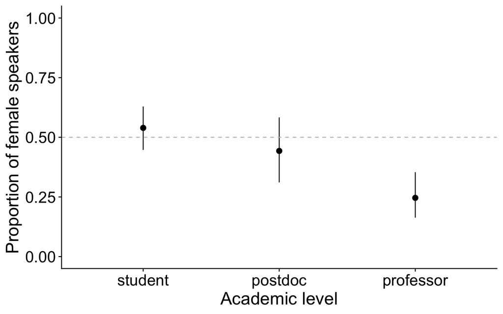

# Modeling only speakers from the PPGE community

Subset analysis with only speakers from the PPGE community in order to compare the proportion of female speakers with the proportion of female in the population source.

Data form the population of speakers is the proporion of female in each academic level and each year in the PPGE community.

Including the information of the PPGE community in the dataset

```r
data <- data %>% left_join(pop2[,c(1:2,6,9:10)],
                           by=c("year", "position_cat"="category")) %>%
  mutate(position_cat = fct_relevel(position_cat, "student","postdoc",
                                    "professor"))
```

Selecting only speakers of the PPGE community.

```r
datappge <- data %>% filter(department == "Ecologia", institute == "IB",
                            university == "USP")
dim(datappge)
```

```
## [1] 136  36
```

```r
table(datappge$position_cat)
```

```
##
##   student   postdoc professor
##        99        24        13
```

```r
table(datappge$affirm_action)
```

```
##
## before  after
##    109     27
```

## Modeling

```r
mnullppge<- glmmTMB(fem ~ 1 + (1|year),
                  family = binomial, data = datappge)
mod0ppge <- glmmTMB(fem ~ 1 + propFcat + (1|year),
                  family = binomial, data = datappge)
mod1ppge <- glmmTMB(fem ~ affirm_action + propFcat + (1|year),
                  family = binomial, data = datappge)
mod2ppge <- glmmTMB(fem ~ position_cat + propFcat + (1|year),
                  family = binomial, data = datappge)
mod3ppge <- glmmTMB(fem ~ position_cat + affirm_action + propFcat + (1|year),
                  family = binomial, data = datappge)
kable(AICtab(mod0ppge, mod1ppge, mod2ppge, mod3ppge, mnullppge,
             base = T, weights = T), digits = 2)
```

|  | AIC | dAIC | df | weight |
| --- | --- | --- | --- | --- |
| mod0ppge | 186.43 | 0.00 | 3 | 0.33 |
| mod2ppge | 186.64 | 0.21 | 5 | 0.30 |
| mod1ppge | 187.75 | 1.32 | 4 | 0.17 |
| mod3ppge | 187.75 | 1.32 | 6 | 0.17 |
| mnullppge | 192.24 | 5.82 | 2 | 0.02 |

Residual diagnostic of the first 2 best-fitting models.

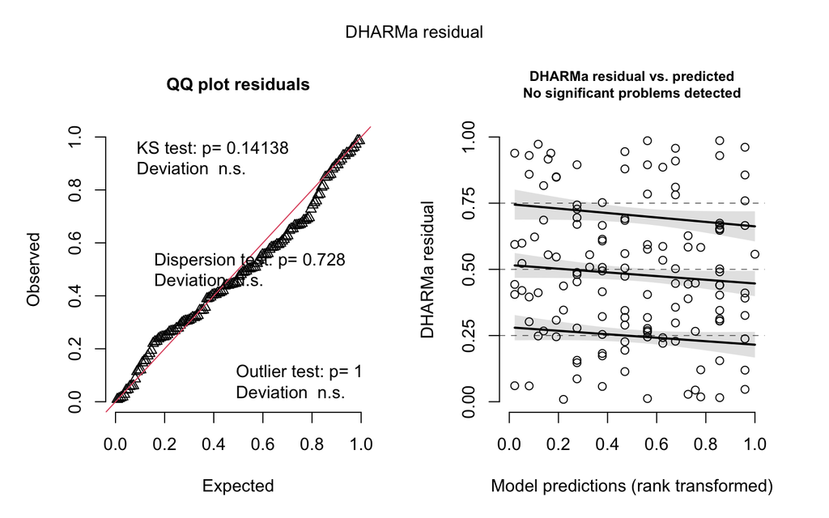

```r
plot(simulateResiduals(mod0ppge))
```

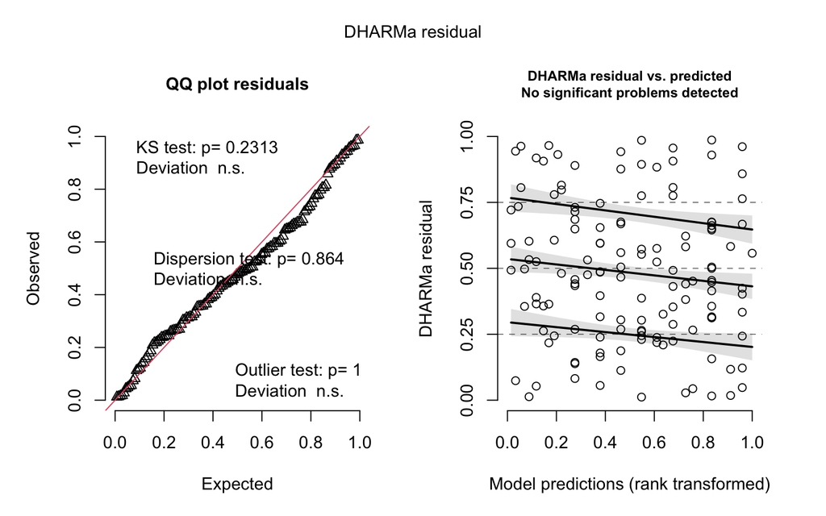

```r
plot(simulateResiduals(mod2ppge))
```

```r
r2(mod0ppge)
```

```
## Random effect variances not available. Returned R2 does not account for random effects.
```

```
## # R2 for Mixed Models
##
##   Conditional R2: NA
##      Marginal R2: 0.073
```

```r
r2(mod2ppge)
```

```
## # R2 for Mixed Models
##
##   Conditional R2: 0.121
##      Marginal R2: 0.120
```

## Model with only the population-level proportion of females

Solid line indicates the model’s prediction. Dashed line indicates the proportions 50% of females for each proportion - relationship 1:1. Dotted horizontal line indicates the 50% of speakers.

```r
datappge$y2 <- datappge$fem
datappge$y2[datappge$position_cat=="postdoc" & datappge$fem==1] <- 1-0.02
datappge$y2[datappge$position_cat=="postdoc" & datappge$fem==0] <- 0+0.02
datappge$y2[datappge$position_cat=="professor" & datappge$fem==1] <- 1-0.04
datappge$y2[datappge$position_cat=="professor" & datappge$fem==0] <- 0+0.04
```

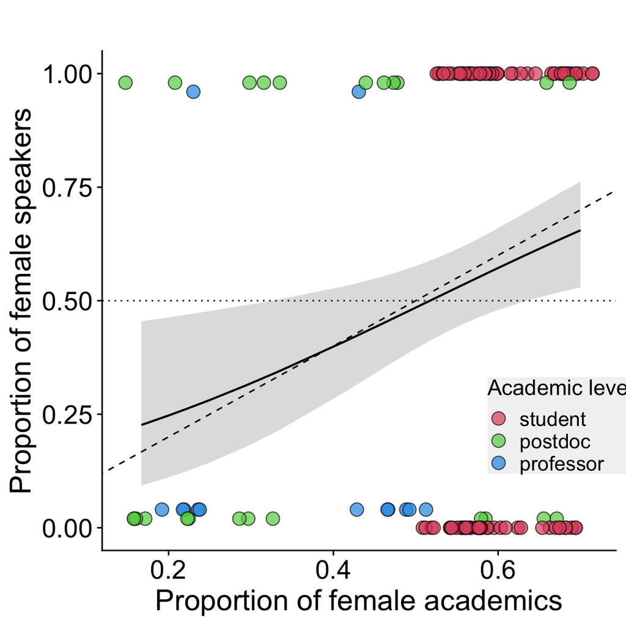

```r
plot(ggpredict(mod0ppge, terms=c("propFcat[all]"))) +
  theme_cowplot() + ggtitle("") +
  geom_abline(slope=1, intercept = 0, linetype="dashed") +
  geom_hline(yintercept = 0.5, linetype="dotted")+
  xlab("Proportion of female academics") +
  ylab("Proportion of female speakers") +
  scale_y_continuous(breaks=c(0,0.25,0.5, 0.75,1))+
  geom_jitter(data=datappge, aes(x=propFcat, y=y2, fill=position_cat, col=position_cat), size=4,
              alpha=0.7, width = 0.02, height=0, shape=21,
              inherit.aes = TRUE)+
  scale_fill_manual(values=2:4, name="Academic level") +
  scale_color_manual(values= rep("black",3), name="Academic level") +
  guides(color = "none", fill=guide_legend(order = 2))+
  theme(text = element_text(size=20),
        axis.text = element_text(size=18),
        legend.title = element_text(size=15),
        legend.text = element_text(size=14),
        legend.position = "inside",
        legend.background = element_rect(fill="gray95"),
        legend.position.inside = c(0.75,0.25))
```

```r
ggsave(here("figures", "FIG_3_propFemalePPGE.png"), width=8, height = 7, dpi=600)
ggsave(here("figures", "FIG_3_propFemalePPGE.pdf"), width=8, height = 7)
```

## Model with academic level and the population-level gender ratio

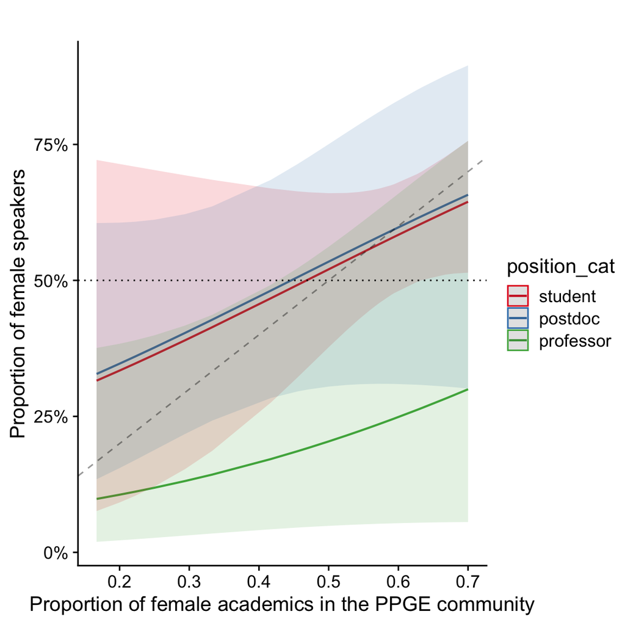

```r
plot(ggpredict(mod2ppge, terms=c("propFcat[all]", "position_cat"))) +
  theme_cowplot() + ggtitle("") +
  geom_hline(yintercept = 0.5, linetype="dotted") +
   geom_abline(slope=1, intercept = 0, linetype="dashed", alpha=0.4) +
  xlab("Proportion of female academics in the PPGE community") +
  ylab("Proportion of female speakers")
```

```r
#ggsave(here("figures", "FIG_S2_propFemalePPGE.jpeg"), width=9, height = 6)
```